# Cyclistic Business Report

Ryan Anderson

September 21, 2025

# Cyclistic Business Report: Understanding Member vs. Casual Riders

## Background

Cyclistic, a fictional bike-share company (whose data is conveniently identical to that published by the real-world company Divvy), has identified that annual members are more profitable than casual riders who purchase single rides or day passes. To inform a marketing strategy that converts more casual riders into members, I examined ride data from July 2024 to July 2025.

Because the dataset included more than 5.5 million rides, I downsampled to a manageable 100,000 rides. Membership rides are more prevalent in the data, outnumbering casual rides by about 2:1. When visualizing count data across groups, this imbalance sometimes made spotting patterns difficult, so I also created two equal groups of 100,000 rides each (members and casuals) using random sampling with replacement (these equalized samples are explicitly indicated in the plot titles when used.)

## Key Findings

### Ride Lengths

Ride Length Summary Statistics (100k Subsample)

| member_casual | Mean | Median | Max | Min | SD |
| --- | --- | --- | --- | --- | --- |
| casual | 24.0 | 11.6 | 1500.0 | 0 | 89 |
| member | 12.1 | 8.5 | 1499.9 | 0 | 27 |

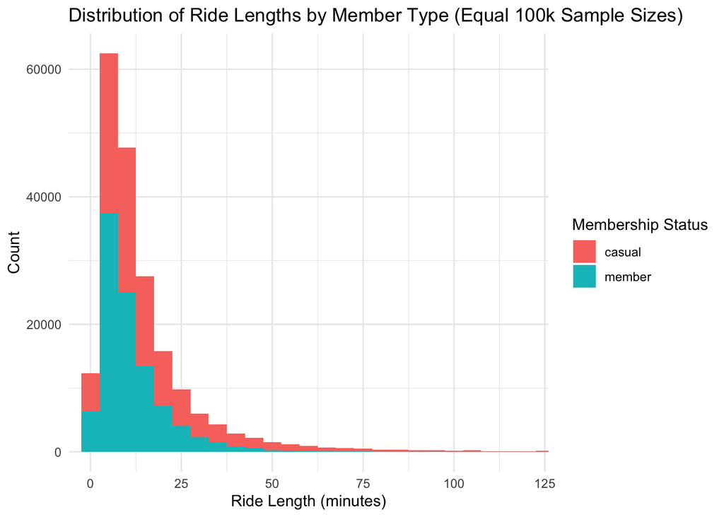

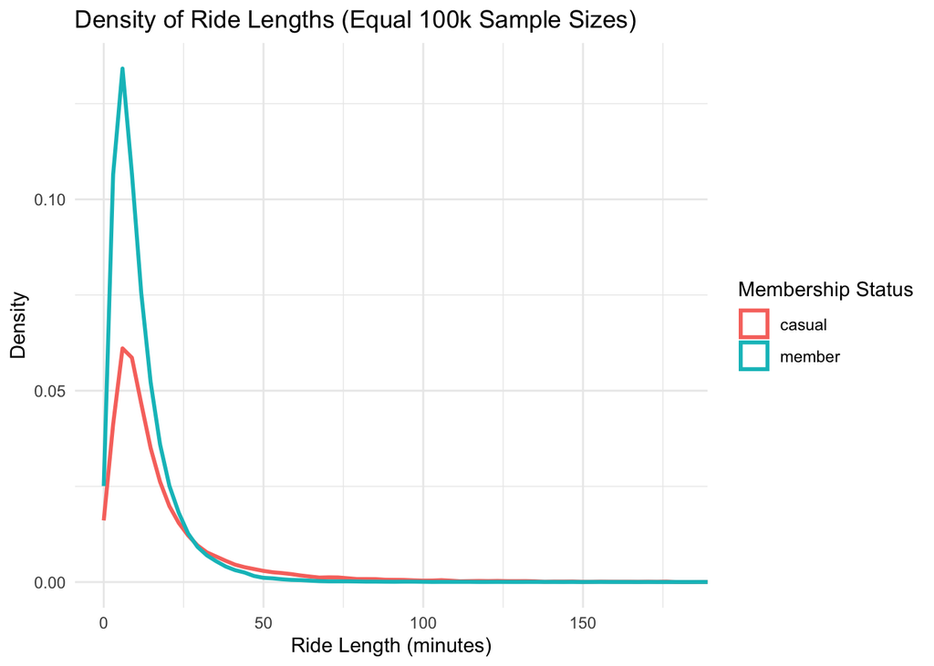

**Variability**: The **standard deviation of ride times** is over three times higher for casual riders compared to members. Members behave predictably, while casuals have much more diverse patterns.

### Ride Frequency by Day

- **Members ride more on weekdays**, peaking on **Tuesday and Thursday**, which aligns with commuting patterns.
- **Casual riders ride more on weekends**, suggesting recreational use. They start to surpass members proportionally on Fridays and carry higher activity into Saturday and Sunday.
- The two groups show opposite patterns resembling a wave function.

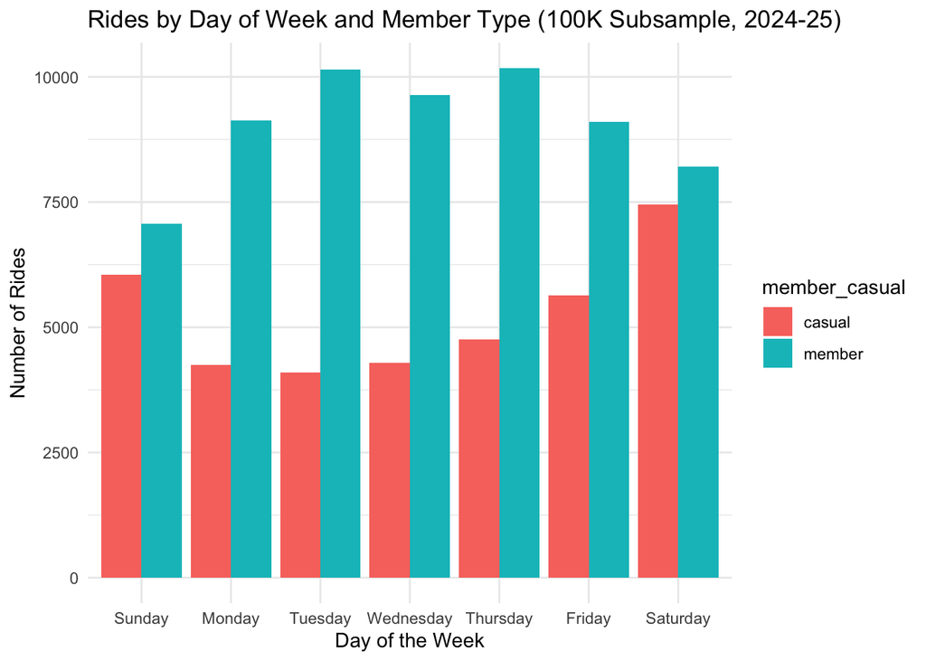

### Ride Length by Day

- Members remain somewhat consistent across the week, with short rides every day.
- Casual riders’ mean ride times dip during the middle of the week. This might be due to fewer long leisure rides occurring then.

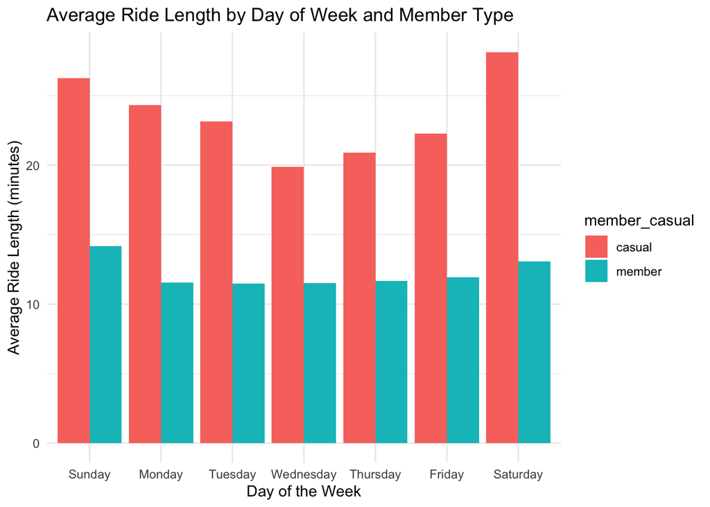

## Business Insights

- Members represent Cyclistic’s **core commuter segment**, focused on reliable, short-distance weekday trips.
- Casual riders are more unpredictable, often leisure-driven, and less reliable for long-term profitability.
- To grow membership, Cyclistic could focus on two pathways:
  1. **Convert casual riders** who already enjoy the service into members by either converting them into consistent commuters or motivating them to more regularly use the service for leisure rides.
  2. **Acquire more commuters** who have not yet used Cyclistic but would benefit from the cost savings and convenience.

## Recommendations (Expanding Core Segment)

- **Expand commuter access**
  - Place bike stations near residential areas and major business districts.
  - Provide easy-to-use route planning tools tailored to commuters.
- **Highlight commuter value**
  - Market speed, reliability, and cost savings compared to driving or transit.
  - Emphasize the eco-friendly and health benefits of cycling to work.
- **Partner with employers**
  - Offer subsidized memberships through corporate wellness programs.
  - Provide flexible commuter-focused plans (e.g., monthly passes or unlimited 30-minute rides).
- **Promote habit formation**
  - Launch rush-hour promotions and “streak” rewards for consistent weekday riding.
  - Use referral programs to encourage coworkers and peer groups to join.
- **Build brand identity**
  - Position Cyclistic as the smart, eco-friendly commuter’s choice.
  - Host local events like bike-to-work days and neighborhood station activations.

## Conclusion

The data confirms that **members are consistent commuters, while casual riders are leisure-focused**. To increase profitability, Cyclistic should double down on its commuting audience by targeting short-distance urban travelers and turning casual users into regular members. By aligning station placement, pricing, and marketing with these insights, Cyclistic can grow its membership base and strengthen long-term revenue.